## Analysis of lecture attendance, engagement and duration

This report analyses lecture engagement based on lecture duration and attendance type.

## variables

- **lecture attendance type**: how the lecture was attended e.g. online(recording) or in-person attendance.
- **lecture engagement**: how engaging the lecture was, using an engagement score from 1(not engaging) to 5(very engaging).
- **lecture duration**: how long the lecture was (measured in hours)

## This report aims to

- analyse how engagement levels differed across attendance types e.g. does engagement vary depending on whether the lecture was attended in-person or online?
- analyse distribution of attendance modes
- analyses distribution of lecture duration (hours)

This section is a summary of the minimum, maximum and mean duration of lectures. This section analyses how engagement differs across attendance modes, which provides a mean engagement level for each mode of attendance.

```
## [1] "Min hours: 1 | Max hours: 3 | Mean hours: 1.29"
```

```
## [1] "Mean engagement: 3"
```

```
## [1] "In-person had a mean engagement of 3.5"
## [2] "Online (recording) had a mean engagement of 2"
```

Graph 1 displays the distribution of lectures attended in-person and lecture recordings watched online.

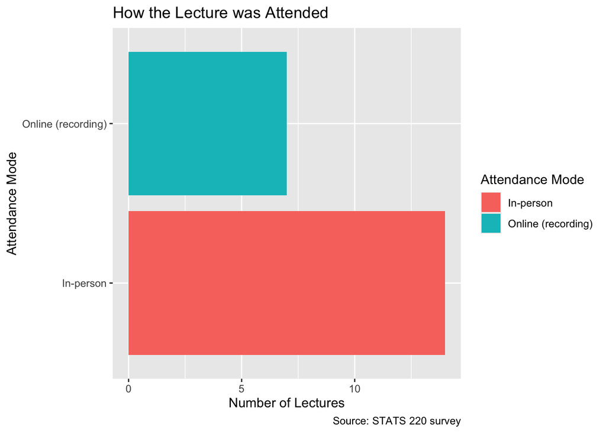

Graph 2 displays the distribution of engagement levels, ranging from 1 to 5.

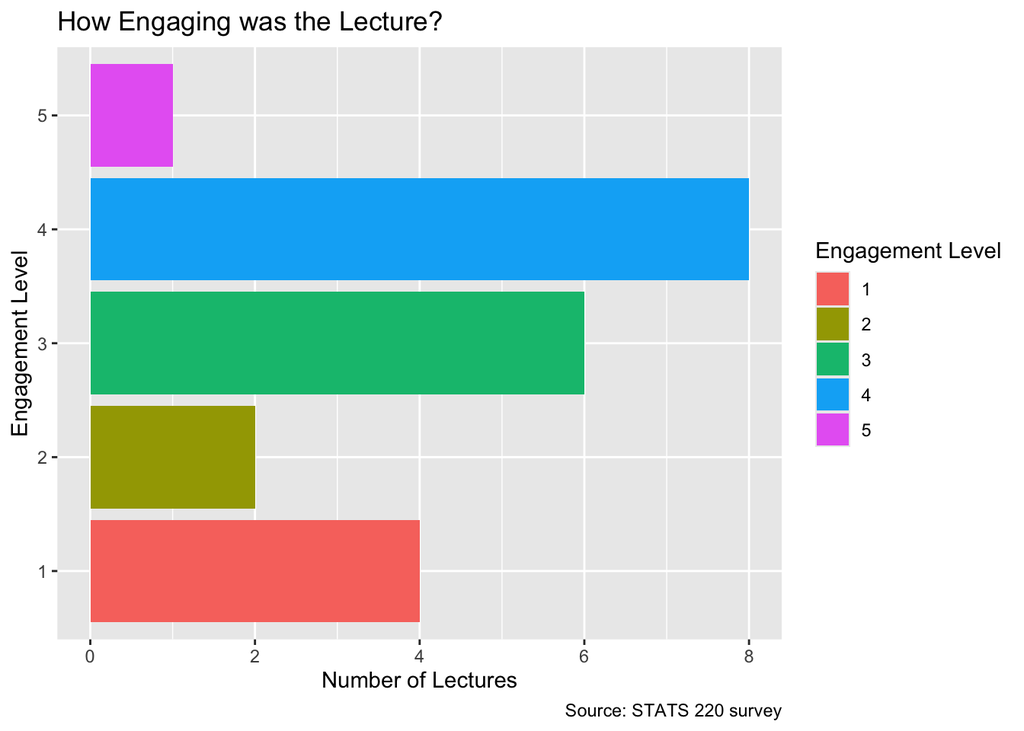

Graph 3 displays the relationship between engagement and attendance mode. The figure exhibits how engagement differs based on whether the lecture was attended in-person or watched online.

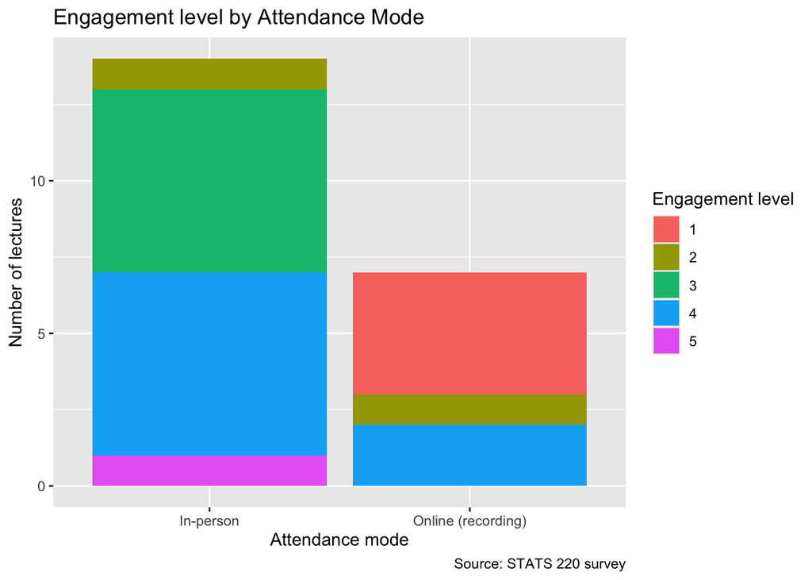

## What’s going on with this data?

This section is an analysis of mean length duration (measured in hours) and mean levels of engagement, measured on a scale from 1 - least engagement, to 5 - most engagement.

```
## [1] "The mean lecture duration was 1.29 hours and the mean level of engagement was 3"
```

This section is an analysis of the minimum and maximum lecture duration (in hours).

```
## [1] "Lecture duration ranged from 1 to 3 hours."
```

This section displays a comparison between mean engagement levels for in-person lecture attendance and online lecture attendance.

```
## [1] "In-person had a mean engagement of 3.5"
## [2] "Online (recording) had a mean engagement of 2"
```